# Overlap and Ontology

This notebook analyzes the filtered data for overlaps between conditions, and for Gene ontology or other functional annotations

```r
library(tidyverse)
library(here)
library(UpSetR)
```

Read in CHIKV hits file. Generated from Initial Protein Filtering RMD

```r
virclasp <- readRDS(here("CHIKV_Hits.rds"))
```

## Generate UpSet diagram

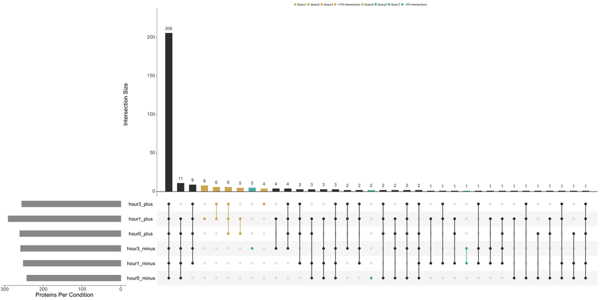

```r
upset_frame <- virclasp %>%
  unite(col = condition, c(Timepoint, IFN), sep = "_") %>%
  select(condition, Accession) %>%
  mutate(exists = 1) %>%
  group_by(Accession) %>%
  spread(condition, exists, fill = 0)
inputData <- as.data.frame(upset_frame)
inputData$Accession <- as.factor(inputData$Accession)
#Define queries for plus IFN and minus IFN. Note that some intersections = 0, so will not be included in query list.
queries <- list(list(query = intersects, params = list("hour3_plus", "hour1_plus", "hour0_plus"), active = T, color = "#d8b365"),
                     list(query = intersects, params = list("hour3_plus", "hour1_plus"), active = T, color = "#d8b365"),
                     list(query = intersects, params = list("hour1_plus", "hour0_plus"), active = T, color = "#d8b365"),
                     list(query = intersects, params = list("hour3_plus"), active = T, color = "#d8b365", query.name = "+ IFN intersections"),
                     list(query = intersects, params = list("hour1_plus"), active = T, color = "#d8b365"),
                     list(query = intersects, params = list("hour3_minus", "hour1_minus"), active = T, color = "#5ab4ac"),
                     list(query = intersects, params = list("hour3_minus"), active = T, color = "#5ab4ac"),
                     list(query = intersects, params = list("hour0_minus"), active = T, color = "#5ab4ac", query.name = "- IFN intersections"))
upset(inputData, nsets = 6,
      order.by = c("freq"),
      sets = c("hour0_minus", "hour1_minus", "hour3_minus", "hour0_plus", "hour1_plus", "hour3_plus"),
      query.legend = "top",
      queries = queries,
      keep.order = TRUE,
      text.scale = 2,
      sets.bar.color = "#999999",
      mainbar.y.label = "Intersection Size",
      sets.x.label = "Proteins Per Condition",
      line.size = 0.8,
      point.size = 3,
      mb.ratio = c(0.65, 0.35))
```

## Gene Ontology

-Output the IDed proteins as a CSV of the Accession numbers. This file will be input into the tools on pantherdb.org

```r
write_csv(data_frame(Accession = virclasp$Accession), here("all_chikv_hits.csv"))
```

```
`data_frame()` is deprecated, use `tibble()`.
```

-Settings for pantherdb.org (Febrauary 28th, 2019): 1. Enter hits file 2. Select “homo sapiens” 3. Select “Statistical overrepresentation test” and default settings 4. Submit 5. Select GO molecular function or GO biological process 6. Fisher’s exact test 7. Use bonferroni correction 8. Run analysis 9. Export files. Located in “Annotations” folder (CHIKV_GO_molecularfxn.txt, CHIKV_GO_biologicalprocess.txt)

Graph - *Remove “Unclassified” annotation prior to ggplot - Add separate “viral” section to the graph

[figure not shown]

```r
molec <- read_tsv(here("Annotations", "CHIKV_GO_molecularfxn.txt"), skip = 12)
biol <- read_tsv(here("Annotations", "CHIKV_GO_biologicalprocess.txt"), skip = 12)
colnames(molec)[1] <- "GO type"
colnames(biol)[1] <- "GO type"
molec_top <- molec %>%
  filter(`GO type` != "Unclassified (UNCLASSIFIED)") %>%
  top_n(n = -10, wt = `all_chikv_hits.csv (P-value)`) %>%
  mutate(`GO analysis` = "molecular function")
biol_top <- biol %>%
  filter(`GO type` != "Unclassified (UNCLASSIFIED)") %>%
  top_n(n = -10, wt = `all_chikv_hits.csv (P-value)`) %>%
  mutate(`GO analysis` = "biological process")
biol_virus <- biol %>%
  filter(`GO type` ==  "antigen processing and presentation (GO:0019882)" | grepl("viral", `GO type`)) %>%
  mutate(`GO analysis` = "biological process") %>%
  mutate(facets = "ZOther enriched terms")
combined_go <- rbind(molec_top, biol_top) %>%
  mutate(facets = "Top 10 terms by statistical significance") %>%
  rbind(biol_virus) %>%
  mutate(`GO type` = gsub("\\s*\\([^\\)]+\\)", "", `GO type`)) %>%
  arrange(`GO analysis`, desc(`all_chikv_hits.csv (P-value)`)) %>%
  mutate(`GO type` = paste(`GO type`, "(p < ", `all_chikv_hits.csv (P-value)`, ")")) %>%
  mutate(`GO type` = forcats::fct_inorder(factor(`GO type`)))
cbPalette <- c("#e5c494", "#999999")
ggplot(combined_go, aes(x = `GO type`, y = `all_chikv_hits.csv (306)`, fill = `GO analysis`)) +
  geom_bar(stat = 'identity') +
  coord_flip() +
  scale_fill_manual(values=cbPalette) +
  geom_text(aes(label = `GO type`, y = 0, hjust = 0), size = 2.5) +
  theme_minimal() +
  theme(axis.text.x = element_text(size = 12),
        axis.text.y = element_blank(),
        axis.title.y = element_blank(),
        panel.grid.major.y = element_blank(),
        strip.text.y = element_text(size = 12)) +
  labs(y = "Number of Proteins", title = "GO analysis of CHIKV VIR-CLASP") +
  facet_wrap(~facets, ncol = 1)
ggsave(here("Figures/CHIKV_GO_030519.pdf"))
```

## Overlaps with previous RBP annotations

### Gerstberger Compilation

- See rtf in “Annotations” folder for explanation of Gerstberger dataset

```r
gerstberger <- read_csv(here("Annotations","Gerstberger_Uniprot.csv")) %>%
  filter(Status == "reviewed") %>%
  select("Accession" = Entry)
```

### GO RNA-binding annotations

- Retrieved from geneontology.org on 05/03/18

```r
go_rbp <- read_tsv(here("Annotations","RNA_binding_GO_050318.txt"), col_names = c("Accession", "Name"))
go_rbp$Accession <- gsub(pattern = "UniProtKB\\:", go_rbp$Accession, replacement = "")
go_rbp$Name = NULL
```

### Castello Interactome

- Same protocol as Gerstberger, Ensembl ID’s were converted to current version, then converted to Uniprot ID`s for comparison

```r
castello <- read_csv(here("Annotations", "HeLaInteractome_uniprot.csv"), col_names = "Accession")
```

## 3 Baltz Interactome

```r
baltz <- read_csv(here("Annotations", "Baltz_uniprot.csv")) %>%
  select(Accession = Entry)
```

## Comparisons between Vir-CLASP, GO Annotated RBP’s, Gerstberger RBP’s, Castello RBP’s, and Baltz RBP’s

```r
virclasp_annotated <- virclasp %>%
  filter(Accession %in% go_rbp$Accession |
         Accession %in% gerstberger$Accession |
         Accession %in% castello$Accession |
         Accession %in% baltz$Accession)
print(paste("Number of annotated RBPs: ", n_distinct(virclasp_annotated$Accession)))
```

```
[1] "Number of annotated RBPs:  127"
```

```r
virclasp_unannotated <- filter(virclasp, !(Accession %in% go_rbp$Accession) &
                                         !(Accession %in% gerstberger$Accession) &
                                         !(Accession %in% castello$Accession &
                                         !(Accession %in% baltz$Accession)))
print(paste("Number of unannotated RBPs: ", n_distinct(virclasp_unannotated$Accession)))
```

```
[1] "Number of unannotated RBPs:  181"
```